# Майнор "Интеллектуальный анализ данных"

# Курс "Современные методы машинного обучения"

# Лабораторная работа №1. Ensembles methods

## Данные

```python
import pandas as pd
import matplotlib.pyplot as plt
import seaborn as sns
```

```python
data = pd.read_csv("london_merged.csv")

data.shape
```

```
(17414, 10)
```

### Признаки

Для каждого дня проката известны следующие признаки (как они были указаны в источнике данных):

- "timestamp" - timestamp field for grouping the data
- "cnt" - the count of a new bike shares - **target variable**
- "t1" - real temperature in C
- "t2" - temperature in C "feels like"
- "hum" - humidity in percentage
- "wind_speed" - wind speed in km/h
- "weather_code" - category of the weather
- "is_holiday" - boolean field - 1 holiday / 0 non holiday
- "is_weekend" - boolean field - 1 if the day is weekend
- "season" - category field meteorological seasons: 0-spring ; 1-summer; 2-fall; 3-winter.

"weathe_code" category description:

- 1 = Clear ; mostly clear but have some values with haze/fog/patches of fog/ fog in vicinity
- 2 = scattered clouds / few clouds
- 3 = Broken clouds
- 4 = Cloudy
- 7 = Rain/ light Rain shower/ Light rain
- 10 = rain with thunderstorm
- 26 = snowfall
- 94 = Freezing Fog

## Часть 1. Предобработка данных (2 балла)

- Выполните необходимые преобразования данных: исправление ошибок, удаление выбросов и пропусков (если это необходимо) , приведение признаков к числовому виду.
- Проведите небольшой EDA анализ и посмотрите как признаки взаимосвязанные между собой и с целевой переменной.
- Feature engineering: создайте новые признаки на основе уже имеющихся.
- Разбейте данные на три группы - тренировочные, валидационные и тестовые. Далее обучайтесь только на тренировочных, оптимизируйте параметры и сравнивайте на валидационных, а тестовые оставьте для итогового сравнения.

```python
import datetime
```

```python
data.head()
```

|  | timestamp | cnt | t1 | t2 | hum | wind_speed | weather_code | is_holiday | is_weekend | season |
| --- | --- | --- | --- | --- | --- | --- | --- | --- | --- | --- |
| 0 | 2015-01-04 00:00:00 | 182 | 3.0 | 2.0 | 93.0 | 6.0 | 3.0 | 0.0 | 1.0 | 3.0 |
| 1 | 2015-01-04 01:00:00 | 138 | 3.0 | 2.5 | 93.0 | 5.0 | 1.0 | 0.0 | 1.0 | 3.0 |
| 2 | 2015-01-04 02:00:00 | 134 | 2.5 | 2.5 | 96.5 | 0.0 | 1.0 | 0.0 | 1.0 | 3.0 |
| 3 | 2015-01-04 03:00:00 | 72 | 2.0 | 2.0 | 100.0 | 0.0 | 1.0 | 0.0 | 1.0 | 3.0 |
| 4 | 2015-01-04 04:00:00 | 47 | 2.0 | 0.0 | 93.0 | 6.5 | 1.0 | 0.0 | 1.0 | 3.0 |

Feature engineering:

Заменим числовые временные значения, на утро,день,вечер и ночь

```python
for i in range(0,len(data['timestamp'])):



    hour=datetime.datetime.strptime(data['timestamp'][i],"%Y-%m-%d %H:%M:%S").hour

    if hour>=0 and hour<=6:
        data['timestamp'][i]='night'
    elif hour>=6 and hour<=12:
        data['timestamp'][i]='morning'
    elif hour>=12 and hour<=17:
        data['timestamp'][i]='day'
    elif hour>=17 and hour<=23:
        data['timestamp'][i]='evening'
```

Создадим новый столбец 'days'. 1-если выходной день, 0- иначе.

```python
data['days']=data['is_holiday']
```

```python
for i in range(0,len(data['is_holiday'])):






    if data['is_holiday'][i]==1:
        data['days'][i]=1
    elif data['is_holiday'][i]==0 and data['is_weekend'][i]==1:
        data['days'][i]=1
    elif data['is_holiday'][i]==0 and data['is_weekend'][i]==0:
        data['days'][i]=0
```

```python
data.info()
```

[output not shown]

```python
cols = data.select_dtypes(include=['int64']).columns
for i in cols:
    print(i, ':', data[i].unique(), '\n')
```

```
cnt : [ 182  138  134 ... 2842   10 2220]
```

```python
cols = data.select_dtypes(include=['float64']).columns
for i in cols:
    print(i, ':', data[i].unique(), '\n')
```

```
t1 : [ 3.          2.5         2.          1.          1.5         4.
  5.          6.          6.5         7.          8.          9.
 10.          9.5         8.5        11.          7.5         5.5
  4.5         3.5        11.5        12.         10.5        12.5
 13.         13.5        15.         15.5        14.          0.5
  0.         -0.5        -1.         -1.5        16.         14.5
 16.5        17.5        17.         18.         19.5        20.5
 20.         18.5        21.5        22.5        22.         23.5
 23.         24.         25.         19.         21.         24.5
 25.5        26.         27.         28.5        29.         30.
 33.         32.         31.5        33.5        34.         29.5
 27.5        26.5        28.         30.5        31.         32.5
 10.33333333]

t2 : [ 2.          2.5         0.         -1.         -0.5        -1.5
  1.5         1.          3.          3.5         4.          4.5
  5.          5.5         6.5         6.          7.5         7.
  8.          8.5         9.         11.         11.5        12.
  9.5        12.5        13.         13.5        15.         15.5
 14.          0.5        -2.         -3.         -2.5        -3.5
 -4.         -6.         -5.5        -4.5        16.         14.5
 10.         16.5        17.5        17.         18.         19.5
 20.5        20.         18.5        21.         21.5        22.5
 22.         23.         24.         19.         10.5        24.5
 25.         23.5        25.5        26.         27.         28.
 27.5        30.         33.         32.         31.5        33.5
 34.         31.         29.5        28.5        26.5        29.
 -5.         30.5        32.5        10.33333333]

hum : [ 93.    96.5  100.    87.    90.    84.    81.    79.    82.    84.5
  90.5   85.    73.5   69.    71.    76.    88.    68.5   78.5   71.5
  62.    80.    74.5   82.5   87.5   79.5   69.5   67.    63.    67.5
  77.    72.    68.    58.    54.    48.    51.5   55.    57.    66.
  72.5   75.    70.    63.5   61.    59.    55.5   56.    60.    64.
  64.5   94.    65.5   76.5   52.    53.    51.    73.    77.5   65.
  78.    86.5   86.    83.    89.5   75.5   62.5   91.    70.5   66.5
  59.5   81.5   50.    61.5   53.5   49.5   46.5   44.5   46.    48.5
  45.5   43.    40.    35.5   47.5   49.    47.    52.5   45.    74.
  44.    41.    39.5   26.    27.    31.    36.5   42.5   50.5   41.5
  72.75  35.    54.5   93.5   97.    33.    39.    37.    32.    36.
```

[output cut: 16 more lines]

```
  3.          2.         16.5         8.5        34.5        43.
 45.5        25.5        26.5         9.5        30.75       47.
 38.5        46.         47.5        46.5        43.5        42.
 15.5        11.5        12.5        14.5        13.5        11.66666667
 35.5        51.         56.5        10.5        39.5        49.5
 56.         52.         54.         50.         36.5         2.66666667
  1.        ]

weather_code : [ 3.  1.  4.  7.  2. 26. 10.]

is_holiday : [0. 1.]

is_weekend : [1. 0.]

season : [3. 0. 1. 2.]
```

```python
A = data.isnull()
A.head()
```

|  | timestamp | cnt | t1 | t2 | hum | wind_speed | weather_code | is_holiday | is_weekend | season |
| --- | --- | --- | --- | --- | --- | --- | --- | --- | --- | --- |
| 0 | False | False | False | False | False | False | False | False | False | False |
| 1 | False | False | False | False | False | False | False | False | False | False |
| 2 | False | False | False | False | False | False | False | False | False | False |
| 3 | False | False | False | False | False | False | False | False | False | False |
| 4 | False | False | False | False | False | False | False | False | False | False |

```python
print('Missing values by features:', A.sum(), sep='\n')#по столбцам
```

```
Missing values by features:
timestamp       0
cnt             0
t1              0
t2              0
hum             0
wind_speed      0
weather_code    0
is_holiday      0
is_weekend      0
season          0
dtype: int64
```

```python
data['weather_code']=data['weather_code'].astype('int64')
data['is_holiday']=data['is_holiday'].astype('int64')
data['is_weekend']=data['is_weekend'].astype('int64')
data['season']=data['season'].astype('int64')
```

```python
data['days']=data['days'].astype('int64')
```

```python
dct={'night':0,'morning':1,'day':2,'evening':3}
data['timestamp']=data['timestamp'].map(dct)
```

```python
data.info()
```

[output not shown]

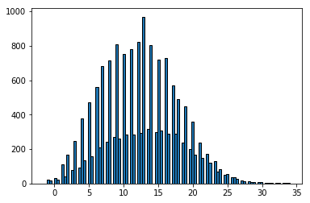

```python
plt.hist(data['t1'], bins = 100, edgecolor = 'k');
```

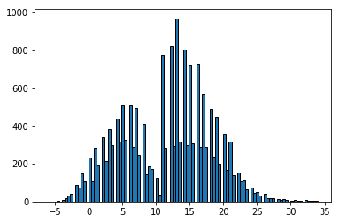

```python
plt.hist(data['t2'], bins = 100, edgecolor = 'k');
```

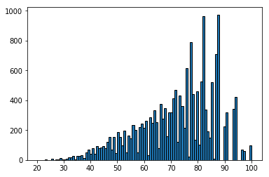

```python
plt.hist(data['hum'], bins = 100, edgecolor = 'k');
```

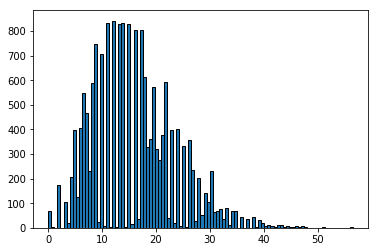

```python
plt.hist(data['wind_speed'], bins = 100, edgecolor = 'k');
```

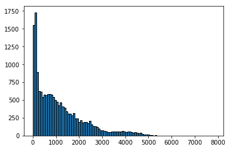

```python
plt.hist(data['cnt'], bins = 100, edgecolor = 'k');
```

Данные графики были построены для выявления возможных аномальных значений. Исходя из визуализации данных можно сделать вывод, что данный датасет не имеет аномальных данных

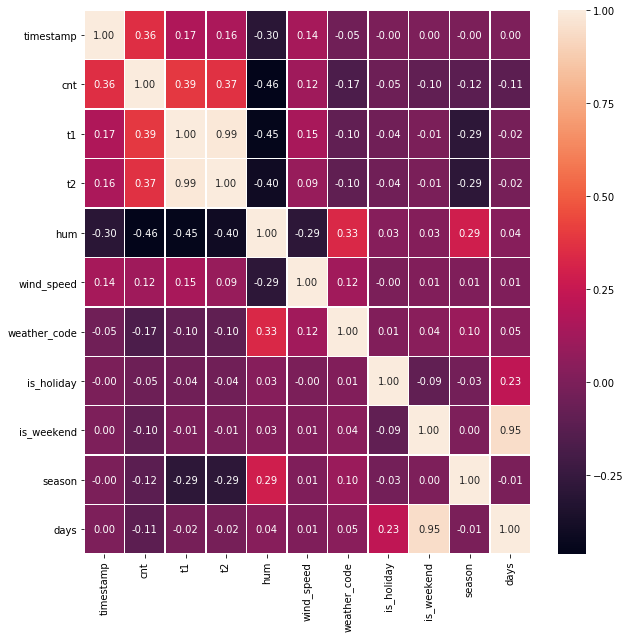

```python
plt.figure(figsize=(10, 10))
sns.heatmap(data.corr(), annot=True, fmt=".2f", linewidths=.5)
```

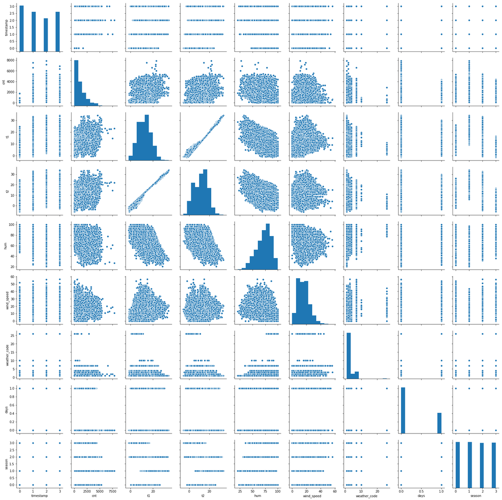

```python
cols=['timestamp','cnt','t1','t2','hum','wind_speed','weather_code','days','season']
sns.pairplot(data[cols])
```

Разбиение данных на 3 группы:

```python
 from sklearn.model_selection import train_test_split
```

```python
df= data.copy()
```

```python
df.head()
```

[output not shown]

```python
X_train,data_X,y_train,data_y=train_test_split(df.drop('cnt',axis=1),df['cnt'],train_size=0.70)
```

```python
val_X,X_test,val_y,y_test=train_test_split(data_X,data_y,test_size=0.30)
```

```python
print(X_train.shape,y_train.shape,X_test.shape,y_test.shape,val_X.shape,val_y.shape)
```

```
(12189, 10) (12189,) (1568, 10) (1568,) (3657, 10) (3657,)
```

## Часть 2. Регрессия **(8 баллов)**

- Решите задачу регрессии: Сравните следующие алгоритмы:
  - Линейную модель (Ridge Regression, Lasso Regression,SVM)
  - Decision trees,
  - Random Forest,
  - Adaboost
  - и градиентные бустинг (xgboost, catboost или lightgbm на выбор).
- Используйте для оценки моделей *MAE, MSE, RMSE, R2, MAPE* метрики.
- Решите задачу регрессии, использовав алгоритмы "из коробки" не прибегая к тюнингу параметров **(4 балла)**.
  - Оцените качество каждой модели. Сравните значение метрики качества на тренировочном датасете (по кросс валидации) и валидационной выборке. Сделайте наблюдения по поведению метрик. Какие плюсы и минусы есть у каждой метрики?
  - Постройте графики предсказания для всех алгоритмов. Сделайте наблюдения, объясните различие в предсказаниях моделей разной природы. Дают ли ансамбли лучший результат?
  - Отобразите важность признаков (feature importance). Можно ли объяснить логически связь между важными признаками и целевой метрикой?
  - Насколько ухудшится качество моделей, если убрать 3 самых незначимых признака?
  - Насколько отличается качество **линейных моделей** если числовые признаки нормализованы (приведены к одному масштабу) и не нормализованы?
  - Насколько отличается качество **"деревянных" моделей** если числовые признаки нормализованы и не нормализованы? Почему?
- На основе полученных метрик выберите алгоритм для дальнейшего исследования.
- Найдите параметры модели, которые дают наилучшие результаты согласно выбранной метрики качества, на валидационной выборке **(1 балла)**
- Проверьте результаты на тестовой выборке **(1 балла)**
- Сделайте выводы на основе сравнения качества моделей **(2 балла)**

```python
from sklearn.linear_model import Lasso
from sklearn import metrics
import numpy as np
from sklearn import preprocessing
```

```python
from sklearn.model_selection import cross_val_score
```

```python
cross_val_score(estimator=Lasso(), X=X_train, y=y_train,
                cv=5, scoring='r2').mean()
```

```
0.31341720623098623
```

```python
regressor = Lasso()
regressor.fit(X_train, y_train)
```

```
Lasso(alpha=1.0, copy_X=True, fit_intercept=True, max_iter=1000,
   normalize=False, positive=False, precompute=False, random_state=None,
   selection='cyclic', tol=0.0001, warm_start=False)
```

```python
y_pred_lasso = regressor.predict(val_X)
```

```python
mse = metrics.mean_squared_error(y_pred=y_pred_lasso,
                                 y_true=val_y)

rmse = np.sqrt(mse)

mae = metrics.mean_absolute_error(y_pred=y_pred_lasso,
                                 y_true=val_y)
def mape_func(y_true, y_pred):
  #  y_true, y_pred = np.array(y_true), np.array(y_pred)
    return np.mean(np.abs((y_true - y_pred) / y_true)) * 100

mape=mape_func(val_y,y_pred_lasso)

R2 = metrics.r2_score(y_pred=y_pred_lasso,
                                 y_true=val_y)
```

```python
print("MSE:   {}\nRMSE:  {}\nR2:    {}\nMAE: {}\nMAPE:   {}".format(mse, rmse, R2, mae,mape))
```

```
MSE:   774418.7537829807
RMSE:  880.0106554940006
R2:    0.3183874395450411
MAE: 650.7862611049917
MAPE:   191.52414865330002
```

Значения коэффициента детерминации сильно не различаются.

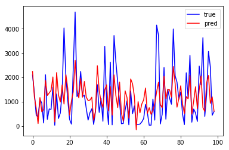

```python
plt.plot(val_y.values[1:100], 'b-', label='true')
plt.plot(y_pred_lasso[1:100], 'r-', label='pred')



plt.legend(loc='best')

plt.show()
```

Важность признаков линейной модели отображается на корреляционной матрице в части 1 данной работы.

Уберем 3 незначительных признака. Выбор данных признаков основывается на показателях корреляции. Уберем те, у которых зависимость с целевой переменной наименьшая.

```python
X_train_new=X_train.copy()
X_train_new=X_train_new.drop('is_holiday',axis=1)
X_train_new=X_train_new.drop('is_weekend',axis=1)
X_train_new=X_train_new.drop('days',axis=1)
```

```python
val_X_new=val_X.copy()
val_X_new=val_X_new.drop('is_holiday',axis=1)
val_X_new=val_X_new.drop('is_weekend',axis=1)
val_X_new=val_X_new.drop('days',axis=1)
```

```python
regressor.fit(X_train_new,y_train)
```

```
Lasso(alpha=1.0, copy_X=True, fit_intercept=True, max_iter=1000,
   normalize=False, positive=False, precompute=False, random_state=None,
   selection='cyclic', tol=0.0001, warm_start=False)
```

```python
y_pred_lasso = regressor.predict(val_X_new)
```

```python
mse = metrics.mean_squared_error(y_pred=y_pred_lasso,
                                 y_true=val_y)

rmse = np.sqrt(mse)

mae = metrics.mean_absolute_error(y_pred=y_pred_lasso,
                                 y_true=val_y)
def mape_func(y_true, y_pred):
  #  y_true, y_pred = np.array(y_true), np.array(y_pred)
    return np.mean(np.abs((y_true - y_pred) / y_true)) * 100

mape=mape_func(val_y,y_pred_lasso)

R2 = metrics.r2_score(y_pred=y_pred_lasso,
                                 y_true=val_y)
```

```python
print("MSE:   {}\nRMSE:  {}\nR2:    {}\nMAE: {}\nMAPE:   {}".format(mse, rmse, R2, mae,mape))
```

```
MSE:   784202.6142594639
RMSE:  885.5521521962802
R2:    0.3097760750114046
MAE: 646.225211305667
MAPE:   183.04431167577408
```

Качество модели ухудшилось незначительно - на 1%.

Модель на нормализованных данных:

```python
X_train_norm=pd.DataFrame(preprocessing.normalize(X_train,norm='l2'),columns=X_train.columns)
```

```python
val_X_norm=pd.DataFrame(preprocessing.normalize(val_X,norm='l2'),columns=val_X.columns)
```

```python
regressor_norm = Lasso()
regressor_norm.fit(X_train_norm, y_train)
```

```
Lasso(alpha=1.0, copy_X=True, fit_intercept=True, max_iter=1000,
   normalize=False, positive=False, precompute=False, random_state=None,
   selection='cyclic', tol=0.0001, warm_start=False)
```

```python
y_pred_lasso_norm = regressor_norm.predict(val_X_norm)
```

```python
mse = metrics.mean_squared_error(y_pred=y_pred_lasso_norm,
                                 y_true=val_y)

rmse = np.sqrt(mse)

mae = metrics.mean_absolute_error(y_pred=y_pred_lasso_norm,
                                 y_true=val_y)
def mape_func(y_true, y_pred):
  #  y_true, y_pred = np.array(y_true), np.array(y_pred)
    return np.mean(np.abs((y_true - y_pred) / y_true)) * 100

mape=mape_func(val_y,y_pred_lasso_norm)

R2 = metrics.r2_score(y_pred=y_pred_lasso_norm,
                                 y_true=val_y)
```

```python
print("MSE:   {}\nRMSE:  {}\nR2:    {}\nMAE: {}\nMAPE:   {}".format(mse, rmse, R2, mae,mape))
```

```
MSE:   788196.7793878932
RMSE:  887.8044713718743
R2:    0.30626056985767547
MAE: 652.3987937243826
MAPE:   206.52588460062907
```

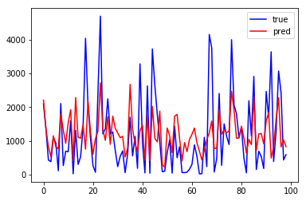

```python
plt.plot(val_y.values[1:100], 'b-', label='true')
plt.plot(y_pred_lasso_norm[1:100], 'r-', label='pred')



plt.legend(loc='best')

plt.show()
```

Качество модели на нормализованных даных разлчается незначительно и составляет 30%

Decision Tree

```python
from sklearn.tree import DecisionTreeRegressor
```

```python
cross_val_score(estimator=DecisionTreeRegressor(), X=X_train, y=y_train,
                cv=5, scoring='r2').mean()
```

```
0.2643883857936069
```

```python
tree = DecisionTreeRegressor()
tree.fit(X_train, y_train)
```

```
DecisionTreeRegressor(criterion='mse', max_depth=None, max_features=None,
           max_leaf_nodes=None, min_impurity_decrease=0.0,
           min_impurity_split=None, min_samples_leaf=1,
           min_samples_split=2, min_weight_fraction_leaf=0.0,
           presort=False, random_state=None, splitter='best')
```

```python
y_pred_tree = tree.predict(val_X)
```

```python
mse = metrics.mean_squared_error(y_pred=y_pred_tree,
                                 y_true=val_y)

rmse = np.sqrt(mse)

mae = metrics.mean_absolute_error(y_pred=y_pred_tree,
                                 y_true=val_y)
def mape_func(y_true, y_pred):
  #  y_true, y_pred = np.array(y_true), np.array(y_pred)
    return np.mean(np.abs((y_true - y_pred) / y_true)) * 100

mape=mape_func(val_y,y_pred_tree)

R2 = metrics.r2_score(y_pred=y_pred_tree,
                                 y_true=val_y)
```

```python
print("MSE:   {}\nRMSE:  {}\nR2:    {}\nMAE: {}\nMAPE:   {}".format(mse, rmse, R2, mae,mape))
```

```
MSE:   882874.5757129402
RMSE:  939.6140567876473
R2:    0.22292894229041105
MAE: 579.2939750250661
MAPE:   82.06512065684907
```

Показатель качества на кроссвалидации на 4% выше, но все же остается довольно невысоким (26%).

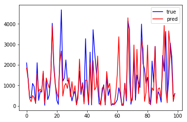

```python
plt.plot(val_y[1:100].values, 'b-', label='true')
plt.plot(y_pred_tree[1:100], 'r-', label='pred')



plt.legend(loc='best')

plt.show()
```

```
[0.3915069  0.14061919 0.05991219 0.15232995 0.13045147 0.05231106
 0.00061316 0.0036466  0.03391427 0.03469522]
```

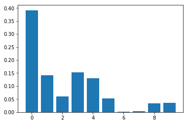

```python
print(tree.feature_importances_)
plt.bar(range(len(tree.feature_importances_)), tree.feature_importances_)
plt.show()
```

Убиарем 3 самых незначительных признака:

```python
X_train_new=X_train.copy()
```

```python
X_train_new=X_train_new.drop('is_holiday',axis=1)
```

```python
X_train_new=X_train_new.drop('is_weekend',axis=1)
```

```python
X_train_new=X_train_new.drop('season',axis=1)
```

```python
tree.fit(X_train_new,y_train)
```

```
DecisionTreeRegressor(criterion='mse', max_depth=None, max_features=None,
           max_leaf_nodes=None, min_impurity_decrease=0.0,
           min_impurity_split=None, min_samples_leaf=1,
           min_samples_split=2, min_weight_fraction_leaf=0.0,
           presort=False, random_state=None, splitter='best')
```

```python
val_X_new=val_X.copy()
val_X_new=val_X_new.drop('is_holiday',axis=1)
val_X_new=val_X_new.drop('is_weekend',axis=1)
val_X_new=val_X_new.drop('season',axis=1)
```

```python
y_pred_tree = tree.predict(val_X_new)
```

```python
mse = metrics.mean_squared_error(y_pred=y_pred_tree,
                                 y_true=val_y)

rmse = np.sqrt(mse)

mae = metrics.mean_absolute_error(y_pred=y_pred_tree,
                                 y_true=val_y)
def mape_func(y_true, y_pred):
  #  y_true, y_pred = np.array(y_true), np.array(y_pred)
    return np.mean(np.abs((y_true - y_pred) / y_true)) * 100

mape=mape_func(val_y,y_pred_tree)

R2 = metrics.r2_score(y_pred=y_pred_tree,
                                 y_true=val_y)
```

```python
print("MSE:   {}\nRMSE:  {}\nR2:    {}\nMAE: {}\nMAPE:   {}".format(mse, rmse, R2, mae,mape))
```

```
MSE:   907909.7908862759
RMSE:  952.8430043224728
R2:    0.20089394245023384
MAE: 595.3119314556558
MAPE:   86.5740853402189
```

Качество модели снизилось незначительно на 2%.

Модель на нормализованных данных:

```python
tree_norm = DecisionTreeRegressor()
tree_norm.fit(X_train_norm, y_train)
```

```
DecisionTreeRegressor(criterion='mse', max_depth=None, max_features=None,
           max_leaf_nodes=None, min_impurity_decrease=0.0,
           min_impurity_split=None, min_samples_leaf=1,
           min_samples_split=2, min_weight_fraction_leaf=0.0,
           presort=False, random_state=None, splitter='best')
```

```python
y_pred_tree_norm = tree_norm.predict(val_X_norm)
```

```python
mse = metrics.mean_squared_error(y_pred=y_pred_tree_norm,
                                 y_true=val_y)

rmse = np.sqrt(mse)

mae = metrics.mean_absolute_error(y_pred=y_pred_tree_norm,
                                 y_true=val_y)
def mape_func(y_true, y_pred):
  #  y_true, y_pred = np.array(y_true), np.array(y_pred)
    return np.mean(np.abs((y_true - y_pred) / y_true)) * 100

mape=mape_func(val_y,y_pred_tree_norm)

R2 = metrics.r2_score(y_pred=y_pred_tree_norm,
                                 y_true=val_y)
```

```python
print("MSE:   {}\nRMSE:  {}\nR2:    {}\nMAE: {}\nMAPE:   {}".format(mse, rmse, R2, mae,mape))
```

```
MSE:   963990.1059441557
RMSE:  981.8299781246017
R2:    0.1515342814774131
MAE: 615.5982317017592
MAPE:   86.93969266415773
```

Качество модели ухудшилось на 7% и составляет 15%.

Random Forest

```python
from sklearn.ensemble import RandomForestRegressor
```

```python
cross_val_score(estimator=RandomForestRegressor(), X=X_train, y=y_train,
                cv=5, scoring='r2').mean()
```

```
0.546943295950844
```

```python
random_tree = RandomForestRegressor( )
random_tree.fit(X_train, y_train)
```

```
RandomForestRegressor(bootstrap=True, criterion='mse', max_depth=None,
           max_features='auto', max_leaf_nodes=None,
           min_impurity_decrease=0.0, min_impurity_split=None,
           min_samples_leaf=1, min_samples_split=2,
           min_weight_fraction_leaf=0.0, n_estimators=10, n_jobs=None,
           oob_score=False, random_state=None, verbose=0, warm_start=False)
```

```python
y_pred_random_tree = random_tree.predict(val_X)
```

```python
mse = metrics.mean_squared_error(y_pred=y_pred_random_tree,
                                 y_true=val_y)

rmse = np.sqrt(mse)

mae = metrics.mean_absolute_error(y_pred=y_pred_random_tree,
                                 y_true=val_y)
def mape_func(y_true, y_pred):
  #  y_true, y_pred = np.array(y_true), np.array(y_pred)
    return np.mean(np.abs((y_true - y_pred) / y_true)) * 100

mape=mape_func(val_y,y_pred_random_tree)

R2 = metrics.r2_score(y_pred=y_pred_random_tree,
                                 y_true=val_y)
```

```python
print("MSE:   {}\nRMSE:  {}\nR2:    {}\nMAE: {}\nMAPE:   {}".format(mse, rmse, R2, mae,mape))
```

```
MSE:   536081.2516593382
RMSE:  732.1756972607997
R2:    0.5281626216172206
MAE: 485.2917644569449
MAPE:   75.16475764334025
```

Значение кроссвалидации выше на 2% и составляет примерно 54%. Модель не соверешнна, но это неплохой показатель.

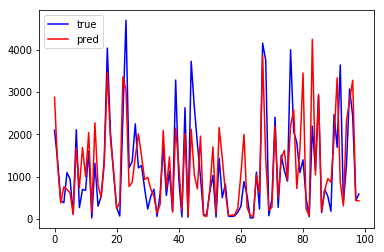

```python
plt.plot(val_y[1:100].values, 'b-', label='true')
plt.plot(y_pred_random_tree[1:100], 'r-', label='pred')



plt.legend(loc='best')

plt.show()
```

```
[0.3877468  0.09978098 0.10036639 0.1583301  0.12557458 0.05282039
 0.00048303 0.00521031 0.0345107  0.03517673]
```

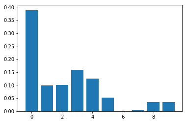

```python
print(random_tree.feature_importances_)
plt.bar(range(len(random_tree.feature_importances_)), random_tree.feature_importances_)
plt.show()
```

Уберем 3 незначительных признака:

```python
random_tree.fit(X_train_new, y_train)
```

```
RandomForestRegressor(bootstrap=True, criterion='mse', max_depth=None,
           max_features='auto', max_leaf_nodes=None,
           min_impurity_decrease=0.0, min_impurity_split=None,
           min_samples_leaf=1, min_samples_split=2,
           min_weight_fraction_leaf=0.0, n_estimators=10, n_jobs=None,
           oob_score=False, random_state=None, verbose=0, warm_start=False)
```

```python
y_pred_random_tree = random_tree.predict(val_X_new)
```

```python
mse = metrics.mean_squared_error(y_pred=y_pred_random_tree,
                                 y_true=val_y)

rmse = np.sqrt(mse)

mae = metrics.mean_absolute_error(y_pred=y_pred_random_tree,
                                 y_true=val_y)
def mape_func(y_true, y_pred):
  #  y_true, y_pred = np.array(y_true), np.array(y_pred)
    return np.mean(np.abs((y_true - y_pred) / y_true)) * 100

mape=mape_func(val_y,y_pred_random_tree)

R2 = metrics.r2_score(y_pred=y_pred_random_tree,
                                 y_true=val_y)
```

```python
print("MSE:   {}\nRMSE:  {}\nR2:    {}\nMAE: {}\nMAPE:   {}".format(mse, rmse, R2, mae,mape))
```

```
MSE:   571796.378328891
RMSE:  756.1721882804809
R2:    0.49672758880417356
MAE: 501.87332161412553
MAPE:   78.55917619033053
```

Качество модели ухудшилось на 3%.

Модель на нормализованных данных:

```python
random_tree_norm = RandomForestRegressor( )
random_tree_norm.fit(X_train_norm, y_train)
```

```
RandomForestRegressor(bootstrap=True, criterion='mse', max_depth=None,
           max_features='auto', max_leaf_nodes=None,
           min_impurity_decrease=0.0, min_impurity_split=None,
           min_samples_leaf=1, min_samples_split=2,
           min_weight_fraction_leaf=0.0, n_estimators=10, n_jobs=None,
           oob_score=False, random_state=None, verbose=0, warm_start=False)
```

```python
y_pred_random_tree_norm = random_tree_norm.predict(val_X_norm)
```

```python
mse = metrics.mean_squared_error(y_pred=y_pred_random_tree_norm,
                                 y_true=val_y)

rmse = np.sqrt(mse)

mae = metrics.mean_absolute_error(y_pred=y_pred_random_tree_norm,
                                 y_true=val_y)
def mape_func(y_true, y_pred):
  #  y_true, y_pred = np.array(y_true), np.array(y_pred)
    return np.mean(np.abs((y_true - y_pred) / y_true)) * 100

mape=mape_func(val_y,y_pred_random_tree_norm)

R2 = metrics.r2_score(y_pred=y_pred_random_tree_norm,
                                 y_true=val_y)
```

```python
print("MSE:   {}\nRMSE:  {}\nR2:    {}\nMAE: {}\nMAPE:   {}".format(mse, rmse, R2, mae,mape))
```

```
MSE:   522693.0196007728
RMSE:  722.9751168614123
R2:    0.5399464105412699
MAE: 482.40081101258295
MAPE:   74.51168806758236
```

После нормализации качество модели улучшилось на 1%.

Adaboost

```python
from sklearn.ensemble import AdaBoostRegressor
```

```python
cross_val_score(estimator=AdaBoostRegressor(), X=X_train, y=y_train,
                cv=5, scoring='r2').mean()
```

```
0.3138006824867596
```

```python
boost = AdaBoostRegressor()
boost.fit(X_train, y_train)
```

```
AdaBoostRegressor(base_estimator=None, learning_rate=1.0, loss='linear',
         n_estimators=50, random_state=None)
```

```python
y_pred_boost = boost.predict(val_X)
```

```python
mse = metrics.mean_squared_error(y_pred=y_pred_boost,
                                 y_true=val_y)

rmse = np.sqrt(mse)

mae = metrics.mean_absolute_error(y_pred=y_pred_boost,
                                 y_true=val_y)
def mape_func(y_true, y_pred):
  #  y_true, y_pred = np.array(y_true), np.array(y_pred)
    return np.mean(np.abs((y_true - y_pred) / y_true)) * 100

mape=mape_func(val_y,y_pred_boost)

R2 = metrics.r2_score(y_pred=y_pred_boost,
                                 y_true=val_y)
```

```python
print("MSE:   {}\nRMSE:  {}\nR2:    {}\nMAE: {}\nMAPE:   {}".format(mse, rmse, R2, mae,mape))
```

```
MSE:   843437.5903261445
RMSE:  918.3885835125263
R2:    0.2576398069935294
MAE: 725.1390014294141
MAPE:   153.5343168600858
```

Показатель качества на кроссвалидации составляет 31%, что на 6% выше, чем показатель качества на валидационной выборке.

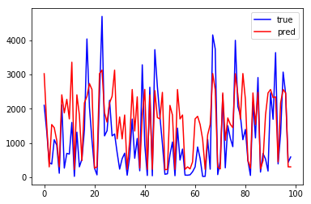

```python
plt.plot(val_y[1:100].values, 'b-', label='true')
plt.plot(y_pred_boost[1:100], 'r-', label='pred')



plt.legend(loc='best')

plt.show()
```

```
[3.08726349e-01 8.83657848e-02 1.29347854e-01 2.60243465e-01
 8.89728833e-02 4.12727137e-02 0.00000000e+00 3.91440346e-07
 1.67234956e-02 6.63470626e-02]
```

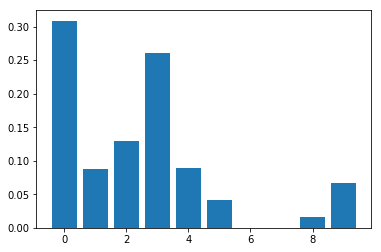

```python
print(boost.feature_importances_)
plt.bar(range(len(boost.feature_importances_)), boost.feature_importances_)
plt.show()
```

Уберем 3 незначительных признака:

```python
boost.fit(X_train_new, y_train)
```

```
AdaBoostRegressor(base_estimator=None, learning_rate=1.0, loss='linear',
         n_estimators=50, random_state=None)
```

```python
y_pred_boost = boost.predict(val_X_new)
```

```python
mse = metrics.mean_squared_error(y_pred=y_pred_boost,
                                 y_true=val_y)

rmse = np.sqrt(mse)

mae = metrics.mean_absolute_error(y_pred=y_pred_boost,
                                 y_true=val_y)
def mape_func(y_true, y_pred):
  #  y_true, y_pred = np.array(y_true), np.array(y_pred)
    return np.mean(np.abs((y_true - y_pred) / y_true)) * 100

mape=mape_func(val_y,y_pred_boost)

R2 = metrics.r2_score(y_pred=y_pred_boost,
                                 y_true=val_y)
```

```python
print("MSE:   {}\nRMSE:  {}\nR2:    {}\nMAE: {}\nMAPE:   {}".format(mse, rmse, R2, mae,mape))
```

```
MSE:   774748.8566287508
RMSE:  880.1981916754605
R2:    0.3180968961603159
MAE: 689.8186472915704
MAPE:   135.8511441953075
```

Качество модели улучшилось на 6% при условии, что 3 самых незначительных признака не были учтены.

Модель на нормализованных данных:

```python
boost_norm = AdaBoostRegressor()
boost_norm.fit(X_train_norm, y_train)
```

```
AdaBoostRegressor(base_estimator=None, learning_rate=1.0, loss='linear',
         n_estimators=50, random_state=None)
```

```python
y_pred_boost_norm = boost_norm.predict(val_X_norm)
```

```python
mse = metrics.mean_squared_error(y_pred=y_pred_boost_norm,
                                 y_true=val_y)

rmse = np.sqrt(mse)

mae = metrics.mean_absolute_error(y_pred=y_pred_boost_norm,
                                 y_true=val_y)
def mape_func(y_true, y_pred):
  #  y_true, y_pred = np.array(y_true), np.array(y_pred)
    return np.mean(np.abs((y_true - y_pred) / y_true)) * 100

mape=mape_func(val_y,y_pred_boost_norm)

R2 = metrics.r2_score(y_pred=y_pred_boost_norm,
                                 y_true=val_y)
```

```python
print("MSE:   {}\nRMSE:  {}\nR2:    {}\nMAE: {}\nMAPE:   {}".format(mse, rmse, R2, mae,mape))
```

```
MSE:   805031.9086086669
RMSE:  897.2357040425146
R2:    0.291442959259137
MAE: 708.8164812230365
MAPE:   151.84198015716586
```

Качество модели улучшилось на 4%.

XGBoost

```python
import xgboost as xgb
```

```python
cross_val_score(estimator=xgb.XGBRegressor(), X=X_train, y=y_train,
                cv=5, scoring='r2').mean()
```

```
[00:36:02] WARNING: d:\build\xgboost\xgboost-0.90.git\src\objective\regression_obj.cu:152: reg:linear is now deprecated in favor of reg:squarederror.
```

```
[00:36:02] WARNING: d:\build\xgboost\xgboost-0.90.git\src\objective\regression_obj.cu:152: reg:linear is now deprecated in favor of reg:squarederror.
```

```
[00:36:03] WARNING: d:\build\xgboost\xgboost-0.90.git\src\objective\regression_obj.cu:152: reg:linear is now deprecated in favor of reg:squarederror.
```

```
[00:36:04] WARNING: d:\build\xgboost\xgboost-0.90.git\src\objective\regression_obj.cu:152: reg:linear is now deprecated in favor of reg:squarederror.
```

```
[00:36:05] WARNING: d:\build\xgboost\xgboost-0.90.git\src\objective\regression_obj.cu:152: reg:linear is now deprecated in favor of reg:squarederror.
```

```
0.5626749034748991
```

```python
xgb_model=xgb.XGBRegressor()
xgb_model.fit(X_train,y_train)
```

```
[01:15:08] WARNING: d:\build\xgboost\xgboost-0.90.git\src\objective\regression_obj.cu:152: reg:linear is now deprecated in favor of reg:squarederror.
```

```
XGBRegressor(base_score=0.5, booster='gbtree', colsample_bylevel=1,
       colsample_bynode=1, colsample_bytree=1, gamma=0,
       importance_type='gain', learning_rate=0.1, max_delta_step=0,
       max_depth=3, min_child_weight=1, missing=None, n_estimators=100,
       n_jobs=1, nthread=None, objective='reg:linear', random_state=0,
       reg_alpha=0, reg_lambda=1, scale_pos_weight=1, seed=None,
       silent=None, subsample=1, verbosity=1)
```

```python
y_pred_xgb = xgb_model.predict(val_X)
```

```python
mse = metrics.mean_squared_error(y_pred=y_pred_xgb,
                                 y_true=val_y)

rmse = np.sqrt(mse)

mae = metrics.mean_absolute_error(y_pred=y_pred_xgb,
                                 y_true=val_y)
def mape_func(y_true, y_pred):
  #  y_true, y_pred = np.array(y_true), np.array(y_pred)
    return np.mean(np.abs((y_true - y_pred) / y_true)) * 100

mape=mape_func(val_y,y_pred_xgb)

R2 = metrics.r2_score(y_pred=y_pred_xgb,
                                 y_true=val_y)
```

```python
print("MSE:   {}\nRMSE:  {}\nR2:    {}\nMAE: {}\nMAPE:   {}".format(mse, rmse, R2, mae,mape))
```

```
MSE:   499776.3187206002
RMSE:  706.9485969436535
R2:    0.560116778430491
MAE: 492.99385363125134
MAPE:   86.79300024675521
```

Показатели качества одинаковы и составляют 56%

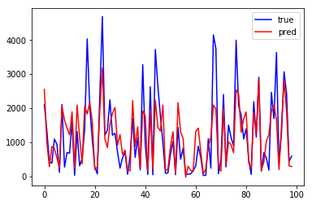

```python
plt.plot(val_y[1:100].values, 'b-', label='true')
plt.plot(y_pred_xgb[1:100], 'r-', label='pred')



plt.legend(loc='best')

plt.show()
```

```
[0.44481057 0.16642407 0.02624323 0.0931174  0.01689345 0.0619804
 0.         0.02228523 0.0663562  0.10188948]
```

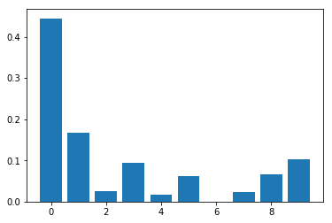

```python
print(xgb_model.feature_importances_)
plt.bar(range(len(xgb_model.feature_importances_)), xgb_model.feature_importances_)
plt.show()
```

Уберем 3 незначительных признака:

```python
X_train_new=X_train.copy()
X_train_new=X_train_new.drop('is_holiday',axis=1)
X_train_new=X_train_new.drop('is_weekend',axis=1)
X_train_new=X_train_new.drop('wind_speed',axis=1)
```

```python
val_X_new=val_X.copy()
val_X_new=val_X_new.drop('is_holiday',axis=1)
val_X_new=val_X_new.drop('is_weekend',axis=1)
val_X_new=val_X_new.drop('wind_speed',axis=1)
```

```python
xgb_model.fit(X_train_new,y_train)
```

```
[14:58:02] WARNING: d:\build\xgboost\xgboost-0.90.git\src\objective\regression_obj.cu:152: reg:linear is now deprecated in favor of reg:squarederror.
```

```
XGBRegressor(base_score=0.5, booster='gbtree', colsample_bylevel=1,
       colsample_bynode=1, colsample_bytree=1, gamma=0,
       importance_type='gain', learning_rate=0.1, max_delta_step=0,
       max_depth=3, min_child_weight=1, missing=None, n_estimators=100,
       n_jobs=1, nthread=None, objective='reg:linear', random_state=0,
       reg_alpha=0, reg_lambda=1, scale_pos_weight=1, seed=None,
       silent=None, subsample=1, verbosity=1)
```

```python
y_pred_xgb = xgb_model.predict(val_X_new)
```

```python
mse = metrics.mean_squared_error(y_pred=y_pred_xgb,
                                 y_true=val_y)

rmse = np.sqrt(mse)

mae = metrics.mean_absolute_error(y_pred=y_pred_xgb,
                                 y_true=val_y)
def mape_func(y_true, y_pred):
  #  y_true, y_pred = np.array(y_true), np.array(y_pred)
    return np.mean(np.abs((y_true - y_pred) / y_true)) * 100

mape=mape_func(val_y,y_pred_xgb)

R2 = metrics.r2_score(y_pred=y_pred_xgb,
                                 y_true=val_y)
```

```python
print("MSE:   {}\nRMSE:  {}\nR2:    {}\nMAE: {}\nMAPE:   {}".format(mse, rmse, R2, mae,mape))
```

```
MSE:   503233.67475328606
RMSE:  709.3896494545759
R2:    0.5570737512745348
MAE: 494.8766394814149
MAPE:   84.94958790635137
```

Качество данной модели понизилось на 1% без 3 признаков.

Модель на нормализованных данных:

```python
xgb_model_norm=xgb.XGBRegressor()
xgb_model_norm.fit(X_train_norm,y_train)
```

```
[02:42:46] WARNING: d:\build\xgboost\xgboost-0.90.git\src\objective\regression_obj.cu:152: reg:linear is now deprecated in favor of reg:squarederror.
```

```
XGBRegressor(base_score=0.5, booster='gbtree', colsample_bylevel=1,
       colsample_bynode=1, colsample_bytree=1, gamma=0,
       importance_type='gain', learning_rate=0.1, max_delta_step=0,
       max_depth=3, min_child_weight=1, missing=None, n_estimators=100,
       n_jobs=1, nthread=None, objective='reg:linear', random_state=0,
       reg_alpha=0, reg_lambda=1, scale_pos_weight=1, seed=None,
       silent=None, subsample=1, verbosity=1)
```

```python
y_pred_xgb_norm = xgb_model_norm.predict(val_X_norm)
```

```python
mse = metrics.mean_squared_error(y_pred=y_pred_xgb_norm,
                                 y_true=val_y)

rmse = np.sqrt(mse)

mae = metrics.mean_absolute_error(y_pred=y_pred_xgb_norm,
                                 y_true=val_y)
def mape_func(y_true, y_pred):
  #  y_true, y_pred = np.array(y_true), np.array(y_pred)
    return np.mean(np.abs((y_true - y_pred) / y_true)) * 100

mape=mape_func(val_y,y_pred_xgb_norm)

R2 = metrics.r2_score(y_pred=y_pred_xgb_norm,
                                 y_true=val_y)
```

```python
print("MSE:   {}\nRMSE:  {}\nR2:    {}\nMAE: {}\nMAPE:   {}".format(mse, rmse, R2, mae,mape))
```

```
MSE:   495186.64589901606
RMSE:  703.6949949367382
R2:    0.5641564257508699
MAE: 486.50029724362054
MAPE:   86.04802867117996
```

Качество данной модели не изменилось и составляет 56%.

Плюсы и минусы каждой метрики: Преимущества MSE: Подчеркивает большие ошибки над меньших ошибках. Является дифференцируемым, что позволяет более эффективно использовать для поиска минимальных или максимальных значений с помощью математических методов. RMSE легко интерпретировать,оперирует меньшими величинами по абсолютному значению. MSE сильнее штрафует за большие отклонения по сравнению с MAE, и поэтому более чувствителен к выбросам. MSE не позволяет сделать выводов о том, насколько хорошо данная модель решает задачу. Коэффициент детерминации считается по обучающей части выборки, а значит просто показывает, насколько хорошо мы описали данные. При этом точность описания не гарантирует точность прогнозов. В некоторых случаях даже наоборот: излишне точное описание приводит к ухудшению прогнозных свойств модели (так как та начинает слишком сильно реагировать на шум). Низкие значения коэффциента детерминации могут указывать на то, что модель особого смысла не имеет, но при этом высокие значения не говорят о том, что перед нами хорошая модель. Значение MAE сложно интерпретировать. С помощью этого коэффициента можно проводить сравнение только между моделями по одному ряду данных. MAPE очень чувствительный к масштабу. Этот коэффициент жестче относится к случаям завышенных прогнозов, чем заниженных.

Чем ближе значения MSE к нулю, тем лучше. На данных моделях поведение MSE весьма неоднозначное, что указывает на не очнь хорошее качество моделей. RMSE указывает, насколько близко модель прогнозирует замеренные значения. Чем меньше эта ошибка, тем лучше. В данном случае показатели данной ошибки так же очень завышены на всех моделях. Касаемо значения коэффициента детерминации, то лучшее значение показала модель XGBoost, и на кросс валидации, и на обучении этот показатель составляет 56%. Благодаря MAE и MAPE можно сравнить модели между собой( MAPE это показатель MAE в процентах(показатель ошибки)). В целом MAPE достаточно высоки на всех моделях, но если выбирать из того что есть, то показатель лучше чем остальные на моделях Decision Tree, Random tree и XGBoost.

Для дальнейшего исселдования был выбран алгоритм XGBoost.

Проверка результатов на валидационной выборке:

```python
xgb_model=xgb.XGBRegressor( booster='gbtree', gamma=1.2,
learning_rate=0.1,
max_depth=8, n_estimators=40,
n_jobs=2,
reg_alpha=0.9, reg_lambda=0.9)
xgb_model.fit(X_train,y_train)
```

```
[18:29:09] WARNING: d:\build\xgboost\xgboost-0.90.git\src\objective\regression_obj.cu:152: reg:linear is now deprecated in favor of reg:squarederror.
```

```
XGBRegressor(base_score=0.5, booster='gbtree', colsample_bylevel=1,
       colsample_bynode=1, colsample_bytree=1, gamma=1.2,
       importance_type='gain', learning_rate=0.1, max_delta_step=0,
       max_depth=8, min_child_weight=1, missing=None, n_estimators=40,
       n_jobs=2, nthread=None, objective='reg:linear', random_state=0,
       reg_alpha=0.9, reg_lambda=0.9, scale_pos_weight=1, seed=None,
       silent=None, subsample=1, verbosity=1)
```

```python
y_pred_xgb=xgb_model.predict(val_X)
```

```python
mse = metrics.mean_squared_error(y_pred=y_pred_xgb,
                                 y_true=val_y)

rmse = np.sqrt(mse)

mae = metrics.mean_absolute_error(y_pred=y_pred_xgb,
                                 y_true=val_y)
def mape_func(y_true, y_pred):
  #  y_true, y_pred = np.array(y_true), np.array(y_pred)
    return np.mean(np.abs((y_true - y_pred) / y_true)) * 100

mape=mape_func(val_y,y_pred_xgb)

R2 = metrics.r2_score(y_pred=y_pred_xgb,
                                 y_true=val_y)
```

```python
print("MSE:   {}\nRMSE:  {}\nR2:    {}\nMAE: {}\nMAPE:   {}".format(mse, rmse, R2, mae,mape))
```

```
MSE:   453698.4175340915
RMSE:  673.5713900798427
R2:    0.6006727128712629
MAE: 449.03236781061105
MAPE:   69.66549491245479
```

[figure not shown]

```python
plt.plot(y_test[1:100].values, 'b-', label='true')
plt.plot(y_pred_xgb[1:100], 'r-', label='pred')



plt.legend(loc='best')

plt.show()
```

После подбора параметров качество модели возросло на 4%.

Проверка результатов на тестовой выборке:

```python
xgb_model.fit(X_train,y_train)
y_pred_xgb=xgb_model.predict(X_test)
```

```
[18:41:00] WARNING: d:\build\xgboost\xgboost-0.90.git\src\objective\regression_obj.cu:152: reg:linear is now deprecated in favor of reg:squarederror.
```

```python
mse = metrics.mean_squared_error(y_pred=y_pred_xgb,
                                 y_true=y_test)

rmse = np.sqrt(mse)

mae = metrics.mean_absolute_error(y_pred=y_pred_xgb,
                                 y_true=y_test)
def mape_func(y_true, y_pred):
  #  y_true, y_pred = np.array(y_true), np.array(y_pred)
    return np.mean(np.abs((y_true - y_pred) / y_true)) * 100

mape=mape_func(y_test,y_pred_xgb)

R2 = metrics.r2_score(y_pred=y_pred_xgb,
                                 y_true=y_test)
```

```python
print("MSE:   {}\nRMSE:  {}\nR2:    {}\nMAE: {}\nMAPE:   {}".format(mse, rmse, R2, mae,mape))
```

```
MSE:   478557.378231663
RMSE:  691.7784170033516
R2:    0.5994753130166857
MAE: 454.8859164568843
MAPE:   74.20432362661651
```

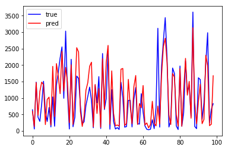

```python
plt.plot(y_test[1:100].values, 'b-', label='true')
plt.plot(y_pred_xgb[1:100], 'r-', label='pred')



plt.legend(loc='best')

plt.show()
```

Прогон модели на тестовой выборке показал качество 59%.